# Homework 4-Main

## Assignment 4: Obsevational Studies and Applied ML

### Deadline

November 21st,11:59PM

### Important notes

Make sure you push on GitHub your notebook with all the cells already evaluated. Don't forget to add a textual description of your thought process, the assumptions you made, and the solution you implemented. Back up any hypotheses and claims with data, since this is an important aspect of the course. Please write all your comments in English, and use meaningful variable names in your code. Your repo should have a single notebook (plus the data files necessary) in the master branch. If there are multiple notebooks present, we will not grade anything.

Use this legendary link to create your repository: [link](https://classroom.github.com/g/YXtsr0QK)

```python
import pandas as pd
import numpy as np
from zipfile import ZipFile
from scipy.stats import pearsonr, chisquare
import matplotlib.pyplot as plt
#Only two classifiers allowed to be used from sklearn
from sklearn.linear_model import LinearRegression, LogisticRegression
from sklearn.ensemble import RandomForestClassifier
from pandas.plotting import scatter_matrix
import seaborn as sns
import random
from scipy import stats
import matplotlib.ticker as mtick
%matplotlib inline
```

```python
data_folder = './data/'
```

## Task 1: Boosting the economy by incentivizing self-employment

Assume the biggest priority of the local government in 2018 is to increase per-capita income. To do so, the officials plan to adopt a strategy for incentivizing self-employment through a series of campaigns, educational programs, and dedicated funds.

Since it is unethical and impossible in this setting to run a controlled experiment involving citizens (e.g., fire employees and force them to self-employ), the officials have asked you, the data scientist, to establish the effect of self-employment on the economy, relying on observational data.

**A)** You will be working with the full US 2015 census dataset (acs2015_county_data.csv, available at https://www.kaggle.com/muonneutrino/us-census-demographic-data#acs2015_county_data.csv). Using suitable methods, determine and quantify the dependency between the percentage of self-employed citizens and per capita income across all 3,212 US counties. Do citizens in counties that have a higher percentage of self-employed people earn more per capita?

**B)** The pilot program will involve all counties within a limited set of three US states. Set A includes Wisconsin, Tennessee, and Minnesota. Quantify the dependency of per-capita income on self-employment rates across all the counties in set A.

**C)** In which state within set A is the observed effect of self-employment on per-capita income the strongest?

**D)** Set B includes New Jersey, Kansas, and Rhode Island. Repeat the analysis from steps B and C above, but now for set B. In which of the two sets A and B (if any) would you recommend incentivizing self-employment? Explain your reasoning.

Hint: It is useful to add a notion of confidence to your results and explore the data visually. You are allowed to use the SciPy library.

```python
zip_path = ZipFile(data_folder+'us-census-demographic-data.zip')
df_america = pd.read_csv(zip_path.open('acs2015_county_data.csv'), encoding='latin1')
df_america.head()
```

|  | CensusId | State | County | TotalPop | Men | Women | Hispanic | White | Black | Native | ... | Walk | OtherTransp | WorkAtHome | MeanCommute | Employed | PrivateWork | PublicWork | SelfEmployed | FamilyWork | Unemployment |
| --- | --- | --- | --- | --- | --- | --- | --- | --- | --- | --- | --- | --- | --- | --- | --- | --- | --- | --- | --- | --- | --- |
| 0 | 1001 | Alabama | Autauga | 55221 | 26745 | 28476 | 2.6 | 75.8 | 18.5 | 0.4 | ... | 0.5 | 1.3 | 1.8 | 26.5 | 23986 | 73.6 | 20.9 | 5.5 | 0.0 | 7.6 |
| 1 | 1003 | Alabama | Baldwin | 195121 | 95314 | 99807 | 4.5 | 83.1 | 9.5 | 0.6 | ... | 1.0 | 1.4 | 3.9 | 26.4 | 85953 | 81.5 | 12.3 | 5.8 | 0.4 | 7.5 |
| 2 | 1005 | Alabama | Barbour | 26932 | 14497 | 12435 | 4.6 | 46.2 | 46.7 | 0.2 | ... | 1.8 | 1.5 | 1.6 | 24.1 | 8597 | 71.8 | 20.8 | 7.3 | 0.1 | 17.6 |
| 3 | 1007 | Alabama | Bibb | 22604 | 12073 | 10531 | 2.2 | 74.5 | 21.4 | 0.4 | ... | 0.6 | 1.5 | 0.7 | 28.8 | 8294 | 76.8 | 16.1 | 6.7 | 0.4 | 8.3 |
| 4 | 1009 | Alabama | Blount | 57710 | 28512 | 29198 | 8.6 | 87.9 | 1.5 | 0.3 | ... | 0.9 | 0.4 | 2.3 | 34.9 | 22189 | 82.0 | 13.5 | 4.2 | 0.4 | 7.7 |

5 rows × 37 columns

```python
# return df of specified states
def select_states(select_only):
    res_states = df_america[df_america["State"].str.contains("|".join(select_only))]
    return res_states

def draw_scatter_for_single_states(df, ax, title,
                                x_data, y_data, color="blue", regColor="red", opacity=0.8, state="all"):
    # add linear regression
    x = df[x_data]
    y = df[y_data]
    slope, intercept, r_value, p_value, std_err = stats.linregress(x, y)
    ax.plot(x, slope*x+intercept, linestyle='solid', lw=3, c=regColor, label='regr. fit '+ state)

    # add regresstion data
    corr, p_val = stats.spearmanr(x, y)
    ax.scatter(x=df["SelfEmployed"], y=df["IncomePerCap"], alpha=opacity, edgecolors=(0, 0, 0), c=color, label=state)
    ax.set_title(title)
    ax.set_xlabel(x_data)
    ax.set_ylabel(y_data)

    dollar_format = '${x:,.0f}'
    ax.yaxis.set_major_formatter(mtick.StrMethodFormatter(dollar_format))
    ax.xaxis.set_major_formatter(mtick.PercentFormatter(decimals=0))

    ax.legend()
    return (slope, intercept, [corr, p_val])

def draw_scatter_states_(df, states, colors=["red", "gold", "green"],
                        x_data="SelfEmployed", y_data="IncomePerCap"):
    data = {}
    fig, ax = plt.subplots(len(states), 1, figsize=(15, 12))
    for idx in range(0, len(states)):
        tmp_df = df_america[df_america["State"] == states[idx]]
        draw_all = draw_scatter_for_single_states(df, ax[idx], title="Self Emplyoment",
                                            x_data=x_data, y_data=y_data,
                                            color="lightgrey", regColor="lightgrey", opacity=0.2)
        single_state_vals = draw_scatter_for_single_states(tmp_df, ax[idx], title="Self Emplyoment",
                                            x_data=x_data, y_data=y_data,
                                            color=colors[idx%len(colors)], regColor=colors[idx%len(colors)],
                                            opacity=1, state=states[idx])
        data[states[idx]] = single_state_vals
    plt.tight_layout()
    return data
```

### A)

Using suitable methods, determine and quantify the dependency between the percentage of self-employed citizens and per capita income across all 3,212 US counties. Do citizens in counties that have a higher percentage of self-employed people earn more per capita?

```
reg. slope           :  138.30914997480608
reg. intercept       :  22884.73105154766
spearman correlation :  0.056413673053189874
spearman p-value     :  0.0013623847564714516

reg. slope           :  -271.16208514464387
reg. intercept       :  28743.6137473879
spearman correlation :  -0.3237163572306909
spearman p-value     :  1.9152631024836546e-79
```

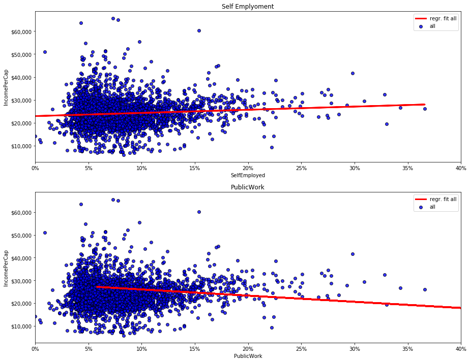

```python
fig, ax = plt.subplots(2, 1, figsize=(15, 12))
ax[0].set_xlim([0,40])
ax[1].set_xlim([0,40])
slope, intercept, [corr, p_val] = draw_scatter_for_single_states(df_america, ax[0], title="Self Emplyoment",
                                                              x_data="SelfEmployed", y_data="IncomePerCap")
print("reg. slope           : ", slope)
print("reg. intercept       : ", intercept)
print("spearman correlation : ", corr)
print("spearman p-value     : ", p_val, "\n")

slope, intercept, [corr, p_val] = draw_scatter_for_single_states(df_america, ax[1], "PublicWork",
                                                              x_data="PublicWork", y_data="IncomePerCap")
print("reg. slope           : ", slope)
print("reg. intercept       : ", intercept)
print("spearman correlation : ", corr)
print("spearman p-value     : ", p_val, "\n")
```

#### Conclusion

H0: citizens in counties that have a higher percentage of self-employed people earn more per capita H1: citizens in counties that have a higher percentage of self-employed people earn NOT more per capita

## B)

The pilot program will involve all counties within a limited set of three US states. Set A includes Wisconsin, Tennessee, and Minnesota. Quantify the dependency of per-capita income on self-employment rates across all the counties in set A.

```
States:  ['Wisconsin', 'Tennessee', 'Minnesota']
reg. slope           :  -357.4213020901421
reg. intercept       :  27797.278449632442
spearman correlation :  -0.2366979000103385
spearman p-value     :  0.00014010090313655094
```

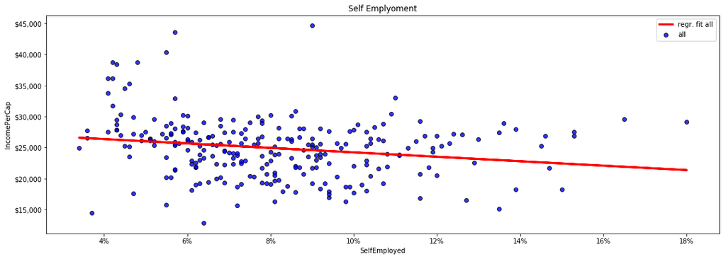

```python
colors = ["orange", "blue", "aqua", "brown", "green"]
states_A = ['Wisconsin','Tennessee','Minnesota']
set_A = select_states(states_A)

fig, ax = plt.subplots(figsize=(18, 6))
slope, intercept, [corr, p_val] = draw_scatter_for_single_states(set_A, ax, title="Self Emplyoment",
                                                              x_data="SelfEmployed", y_data="IncomePerCap")
print("States: ", states_A)
print("reg. slope           : ", slope)
print("reg. intercept       : ", intercept)
print("spearman correlation : ", corr)
print("spearman p-value     : ", p_val, "\n")
```

#### Conclusion

The plot above takes only the three states Wisconsin, Tennessee, and Minnesota into consideration.

## C)

In which state within set A is the observed effect of self-employment on per-capita income the strongest?

```
Wisconsin reg. slope           :  -494.64819570341706
Wisconsin reg. intercept       :  29806.693140223455
Wisconsin spearman correlation :  -0.46351291044049403
Wisconsin p-value              :  4.124859155566003e-05

Tennessee reg. slope           :  -476.089190479663
Tennessee reg. intercept       :  25329.8145795271
Tennessee spearman correlation :  -0.316991392780988
Tennessee p-value              :  0.0017487582457931406

Minnesota reg. slope           :  -285.09596725644064
Minnesota reg. intercept       :  30077.32464540975
Minnesota spearman correlation :  -0.21107460598245847
Minnesota p-value              :  0.04970805582462062
```

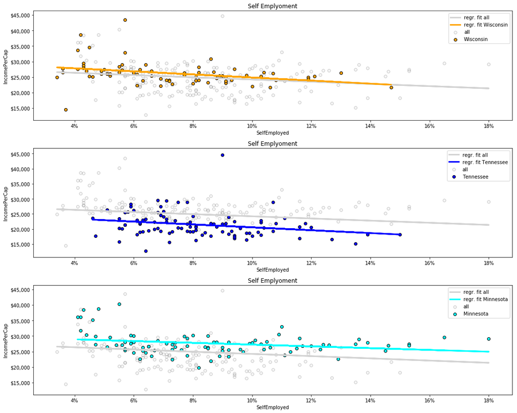

```python
colors = ["orange", "blue", "aqua", "brown", "green"]
res_C = draw_scatter_states_(set_A, states_A, colors)

for key, value in res_C.items():
    print(key, "reg. slope           : ", value[0])
    print(key, "reg. intercept       : ", value[1])
    print(key, "spearman correlation : ", value[2][0])
    print(key, "p-value              : ", value[2][1], "\n")
```

#### Conclusion:

According to the regression data the counties of Minnesota have show the least negative slope as well as the highest intercept which depicts a high income.

## D)

Set B includes New Jersey, Kansas, and Rhode Island. Repeat the analysis from steps B and C above, but now for set B. In which of the two sets A and B (if any) would you recommend incentivizing self-employment? Explain your reasoning.

```
New Jersey reg. slope           :  3863.934831102613
New Jersey reg. intercept       :  17316.84034416826
New Jersey spearman correlation :  0.40403460177366013
New Jersey p-value              :  0.06929493068926951

Kansas reg. slope           :  180.57311134776336
Kansas reg. intercept       :  23024.182841069985
Kansas spearman correlation :  0.28392575483491556
Kansas p-value              :  0.0033332825399419903

Rhode Island reg. slope           :  3080.936828534593
Rhode Island reg. intercept       :  17246.59776536313
Rhode Island spearman correlation :  0.9999999999999999
Rhode Island p-value              :  1.4042654220543672e-24

States:  ['New Jersey', 'Kansas', 'Rhode Island']
reg. slope           :  -309.9965160556779
reg. intercept       :  30112.81399141826
spearman correlation :  -0.16010624610827853
spearman p-value     :  0.06773890774775308
```

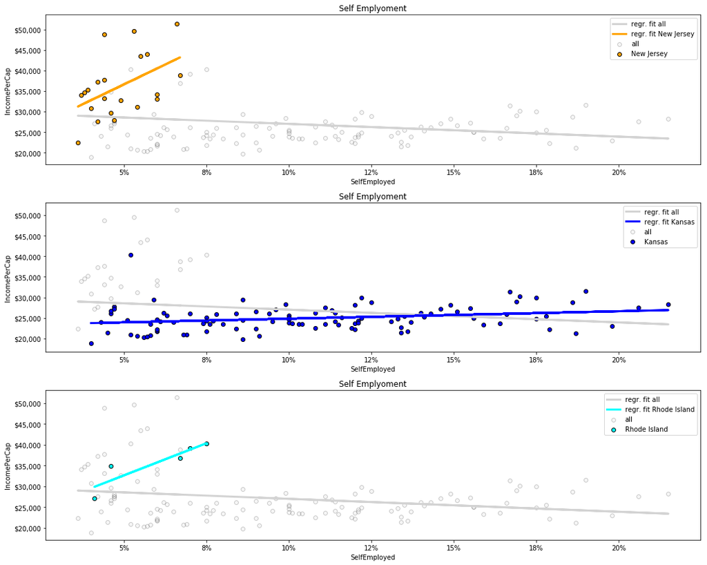

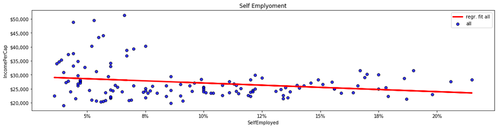

```python
colors = ["orange", "blue", "aqua", "brown", "green"]
states_B = ["New Jersey", "Kansas", "Rhode Island"]
set_B = select_states(states_B)

# compare all 3 counties
res_B = draw_scatter_states_(set_B, states_B, colors)
for key, value in res_B.items():
    print(key, "reg. slope           : ", value[0])
    print(key, "reg. intercept       : ", value[1])
    print(key, "spearman correlation : ", value[2][0])
    print(key, "p-value              : ", value[2][1], "\n")

# all 3 states in one scatter
fig, ax = plt.subplots(figsize=(18, 4))
slope, intercept, [corr, p_val] = draw_scatter_for_single_states(set_B, ax, title="Self Emplyoment",
                                                              x_data="SelfEmployed", y_data="IncomePerCap")
print("States: ", states_B)
print("reg. slope           : ", slope)
print("reg. intercept       : ", intercept)
print("spearman correlation : ", corr)
print("spearman p-value     : ", p_val, "\n")
```

#### Conclusion:

Considering states seperately

- New Jersey has a high p-value: Not significant
- Kansas has a low p-value: significant
- Rhode Island has a low p-value + a very high correlation: significant test to keep Nullhypothesis

Considering all states combined

- high p-value: Not significant

## Task 2: All you need is love… And a dog!

Here we are going to build a classifier to predict whether an animal from an animal shelter will be adopted or not (aac_intakes_outcomes.csv, available at: https://www.kaggle.com/aaronschlegel/austin-animal-center-shelter-intakes-and-outcomes/version/1#aac_intakes_outcomes.csv). You will be working with the following features:

1. *animal_type:* Type of animal. May be one of 'cat', 'dog', 'bird', etc.
2. *intake_year:* Year of intake
3. *intake_condition:* The intake condition of the animal. Can be one of 'normal', 'injured', 'sick', etc.
4. *intake_number:* The intake number denoting the number of occurrences the animal has been brought into the shelter. Values higher than 1 indicate the animal has been taken into the shelter on more than one occasion.
5. *intake_type:* The type of intake, for example, 'stray', 'owner surrender', etc.
6. *sex_upon_intake:* The gender of the animal and if it has been spayed or neutered at the time of intake
7. *age_upon_intake_(years):* The age of the animal upon intake represented in years
8. *time_in_shelter_days:* Numeric value denoting the number of days the animal remained at the shelter from intake to outcome.
9. *sex_upon_outcome:* The gender of the animal and if it has been spayed or neutered at time of outcome
10. *age_upon_outcome_(years):* The age of the animal upon outcome represented in years
11. *outcome_type:* The outcome type. Can be one of ‘adopted’, ‘transferred’, etc.

**A)** Load the dataset and convert categorical features to a suitable numerical representation (use dummy-variable encoding). Split the data into a training set (80%) and a test set (20%). Pair each feature vector with the corresponding label, i.e., whether the outcome_type is adoption or not. Standardize the values of each feature in the data to have mean 0 and variance 1. The use of external libraries is not permitted in part A, except for numpy and pandas.

**B)** Train a logistic regression classifier on your training set. Logistic regression returns probabilities as predictions, so in order to arrive at a binary prediction, you need to put a threshold on the predicted probabilities. For the decision threshold of 0.5, present the performance of your classifier on the test set by displaying the confusion matrix. Based on the confusion matrix, manually calculate accuracy, precision, recall, and F1-score with respect to the positive and the negative class. Vary the value of the threshold in the range from 0 to 1 and visualize the value of accuracy, precision, recall, and F1-score (with respect to both classes) as a function of the threshold. The shelter has a limited capacity and has no other option but to put to sleep animals with a low probability of adoption. What metric (precision, recall, accuracy, or F1-score) and with respect to what class is the most relevant when choosing the threshold in this scenario, and why? Explain your reasoning.

**C)** Reduce the number of features by selecting the subset of the k best features. Use greedy backward selection to iteratively remove features. Evaluate performance and visualize the result using 5-fold cross-validation on the training set as a function of k, where k = 1, 5, 10, 15, 20, 25, 30. Choose the optimal k and justify your choice. Interpret the top-k features and their impact on the probability of adoption.

**D)** Train a random forest. Use 5-fold cross-validation on the training set to fine-tune the parameters of the classifier using a grid search on the number of estimators "n_estimators" and the max depth of the trees "max_depth". For the chosen parameters, estimate the performance of your classifier on the test set by presenting the confusion matrix, accuracy, precision, recall, and F1-score with respect to both classes and compare the performance with the performance of the logistic regression. Interpret the results.

You are allowed to use the scikit-learn library to implement your classifiers.

**A)** Load the dataset and convert categorical features to a suitable numerical representation (use dummy-variable encoding). Split the data into a training set (80%) and a test set (20%). Pair each feature vector with the corresponding label, i.e., whether the outcome_type is adoption or not. Standardize the values of each feature in the data to have mean 0 and variance 1. The use of external libraries is not permitted in part A, except for numpy and pandas.

```python
def read_process_file():
    '''
        Reads the files and converts the cateotry features to dummy variables
        Returns:
           - features datasets
           - class dataset
    '''
    zip_path = ZipFile(data_folder + 'austin-animal-center-shelter-intakes-and-outcomes.zip')
    df_animals = pd.read_csv(zip_path.open('aac_intakes_outcomes.csv'))

    animal_features = ['animal_type','intake_year','intake_condition',
                           'intake_number','intake_type', 'sex_upon_intake',
                           'age_upon_intake_(years)','time_in_shelter_days',
                           'sex_upon_outcome','age_upon_outcome_(years)']

    animal_y = ['outcome_type']

    #Extracting only the features that are needed for the task
    df_animals_features = df_animals[animal_features]
    df_animals_class = df_animals[animal_y]

    #Changing the categorical features into dummie variables with zeros and ones
    animals_training = pd.get_dummies(df_animals_features[animal_features])
    adopted = pd.get_dummies(df_animals_class)

    #Extracting the class value
    animals_adopted = adopted['outcome_type_Adoption']
    return animals_adopted, animals_training
```

```python
animals_adopted, animals_training = read_process_file()
animals_training.head()
```

|  | intake_year | intake_number | age_upon_intake_(years) | time_in_shelter_days | age_upon_outcome_(years) | animal_type_Bird | animal_type_Cat | animal_type_Dog | animal_type_Other | intake_condition_Aged | ... | sex_upon_intake_Intact Female | sex_upon_intake_Intact Male | sex_upon_intake_Neutered Male | sex_upon_intake_Spayed Female | sex_upon_intake_Unknown | sex_upon_outcome_Intact Female | sex_upon_outcome_Intact Male | sex_upon_outcome_Neutered Male | sex_upon_outcome_Spayed Female | sex_upon_outcome_Unknown |
| --- | --- | --- | --- | --- | --- | --- | --- | --- | --- | --- | --- | --- | --- | --- | --- | --- | --- | --- | --- | --- | --- |
| 0 | 2017 | 1.0 | 10.0 | 0.588194 | 10.0 | 0 | 0 | 1 | 0 | 0 | ... | 0 | 0 | 1 | 0 | 0 | 0 | 0 | 1 | 0 | 0 |
| 1 | 2014 | 2.0 | 7.0 | 1.259722 | 7.0 | 0 | 0 | 1 | 0 | 0 | ... | 0 | 0 | 1 | 0 | 0 | 0 | 0 | 1 | 0 | 0 |
| 2 | 2014 | 3.0 | 6.0 | 1.113889 | 6.0 | 0 | 0 | 1 | 0 | 0 | ... | 0 | 0 | 1 | 0 | 0 | 0 | 0 | 1 | 0 | 0 |
| 3 | 2014 | 1.0 | 10.0 | 4.970139 | 10.0 | 0 | 0 | 1 | 0 | 0 | ... | 0 | 0 | 1 | 0 | 0 | 0 | 0 | 1 | 0 | 0 |
| 4 | 2013 | 1.0 | 16.0 | 0.119444 | 16.0 | 0 | 0 | 1 | 0 | 0 | ... | 0 | 0 | 1 | 0 | 0 | 0 | 0 | 1 | 0 | 0 |

5 rows × 32 columns

```python
# Splits the dataset into a two subsets of a preset ratio
def split_to_train_and_test_set(x, y, ratio, seed=1):
    # sets a seed for the split
    np.random.seed(seed)

    # generate random indices
    num_row = len(y)
    indices = np.random.permutation(num_row)
    index_split = int(np.floor(ratio * num_row))
    index_tr = indices[: index_split]
    index_te = indices[index_split:]

    # create split
    x_tr = x[index_tr]
    x_te = x[index_te]
    y_tr = y[index_tr]
    y_te = y[index_te]
    return x_tr, x_te, y_tr, y_te
```

```python
# Perform a split of the data into 80-20 ratio.
x_tr, x_te, y_tr, y_te = split_to_train_and_test_set(animals_training.values,
                                    animals_adopted.values, 0.8)
```

```python
# Standartizes all the columns of the given dataset
def standardize(x):
    centered_data = x - np.mean(x, axis=0)
    std_data = centered_data / np.std(centered_data, axis=0)
    return std_data

st_x_tr = standardize(x_tr)
st_x_te = standardize(x_te)
```

```python
# Verify that all of our columns have a mean of ~0
print("Mean:\n", np.mean(st_x_tr, axis=0))
```

```
Mean:
 [ 2.92092167e-14 -2.17625452e-16  1.38333859e-13  3.45612003e-15
  1.76226444e-13  1.77254255e-15  5.66317733e-15 -6.01879986e-15
 -1.14178418e-15  4.81446254e-15  8.59484405e-16  8.86190062e-16
 -1.06096262e-15  4.63320975e-15 -6.04087342e-16  2.18887771e-16
  7.87379220e-16  1.21889248e-16  9.21256750e-16 -7.98501133e-16
  1.11711042e-15 -1.62090872e-15 -4.50805905e-16 -2.23452045e-16
 -1.63092367e-15  1.70669900e-15  4.31786301e-16 -7.41790697e-16
  1.74498207e-15 -3.74852903e-18 -7.92998530e-16  4.31786301e-16]
```

```python
# Verify all std is 1
print("Variance: \n", np.std(st_x_tr, axis=0))
```

```
Variance:
 [1. 1. 1. 1. 1. 1. 1. 1. 1. 1. 1. 1. 1. 1. 1. 1. 1. 1. 1. 1. 1. 1. 1. 1.
 1. 1. 1. 1. 1. 1. 1. 1.]
```

**Our data frame consists of 32 features, with 5 of them being numerical data and the other 27 being categorical data. After standardizing all of the columns have a mean of 0 and a standard deviation of 1.**

**B)** Train a logistic regression classifier on your training set. Logistic regression returns probabilities as predictions, so in order to arrive at a binary prediction, you need to put a threshold on the predicted probabilities. For the decision threshold of 0.5, present the performance of your classifier on the test set by displaying the confusion matrix. Based on the confusion matrix, manually calculate accuracy, precision, recall, and F1-score with respect to the positive and the negative class. Vary the value of the threshold in the range from 0 to 1 and visualize the value of accuracy, precision, recall, and F1-score (with respect to both classes) as a function of the threshold. The shelter has a limited capacity and has no other option but to put to sleep animals with a low probability of adoption. What metric (precision, recall, accuracy, or F1-score) and with respect to what class is the most relevant when choosing the threshold in this scenario, and why? Explain your reasoning.

```python
# Perform logistic regression on our training set, with a multinomial class
# which calculates the
logistic = LogisticRegression(solver='lbfgs', multi_class='multinomial').fit(st_x_tr, y_tr)
y_pred = logistic.predict_proba(st_x_te)
```

```python
def build_confusion_matrix(predicted, true_values, class_to_choose = 'adopted'):
    '''
    Makes the confusion matrix and manually calculates the values for
    accuracy, precision, recall and f1 score

    'choose' chooses the class with which accuracy, precision,
    recall and f1_score is calculated
    '''

    TP = np.sum(np.logical_and(predicted == 1, true_values == 1))
    TN = np.sum(np.logical_and(predicted == 0, true_values == 0))
    FP = np.sum(np.logical_and(predicted == 1, true_values == 0))
    FN = np.sum(np.logical_and(predicted == 0, true_values == 1))

    # For choose = 1, the function chooses class 'adopted' as the main class
    if class_to_choose == 'adopted':
        accuracy = (TP+TN)/len(true_values)
        precision = TP/(TP+FP)
        recall = TP/(TP+FN)
        f1 = 1/(0.5*(1/precision+1/recall))
    else:
        '''
        For else, the function chooses class 'not adopted' as the main class
        by taking the the True Negative as the value for calculating
        accuracy, precision, recall, f1 score
        '''
        accuracy = (TN+TP)/len(true_values)
        precision = TN/(TN+FN)
        recall = TN/(TN+FP)
        f1 = 1/(0.5*(1/precision+1/recall))
    return accuracy, precision, recall, f1

# Outputs the predictions with a specific threshold
def get_prediction(pred, threshold):
    pred_threshold = (pred > threshold).astype(int)
    return pred_threshold
```

```python
def find_threshold(pred, true_values, class_to_choose):
    '''
    Creates a pandas data frame for plotting the respective values
    with a threshold from 0 to 1.
    Returns:
       - for all the thresholds their accuarcy, precisions, recalls and f1 scores
    '''
    accuracies = []
    precisions = []
    recalls = []
    f1_scores = []
    for i in np.linspace(0, 1, 41):
        predictions = get_prediction(pred, i)
        accu_, prec_, rec_, f1_= build_confusion_matrix(predictions, true_values, class_to_choose)
        accuracies.append(accu_)
        precisions.append(prec_)
        recalls.append(rec_)
        f1_scores.append(f1_)

    df_data = pd.DataFrame(dict(x = np.linspace(0, 1, 41),
                                Accuracy = accuracies,
                                Precision = precisions,
                                Recall = recalls,
                                F1_Score = f1_scores))
    return df_data

df_data_adopted = find_threshold(y_pred[:,1], y_te, class_to_choose='adopted')
df_data_non_adopted = find_threshold(y_pred[:,1], y_te, class_to_choose = 'non_adapted')
```

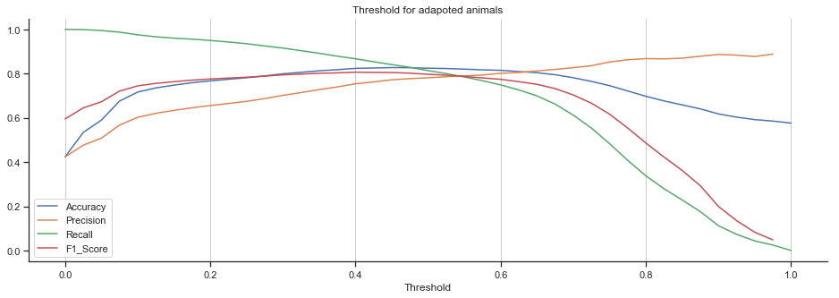

```python
# Plotting values according to the threshold
def add_plot(df, title):
    fig, ax = plt.subplots(figsize=(16, 5))
    # select current axis
    plt.sca(ax)
    # Plot the orbital period with horizontal boxes
    plt.plot('x', 'Accuracy', data = df)#palette="Set3")
    plt.plot('x', 'Precision', data = df)
    plt.plot('x', 'Recall', data = df)
    plt.plot('x', 'F1_Score', data = df)
    plt.legend()

    # Tweak the visual presentation
    ax.xaxis.grid(True)
    ax.set(title=title)
    ax.set(xlabel='Threshold')
    sns.despine(trim=False, left=False)

sns.set(style="ticks")
add_plot(df_data_adopted, "Threshold for adapoted animals")
```

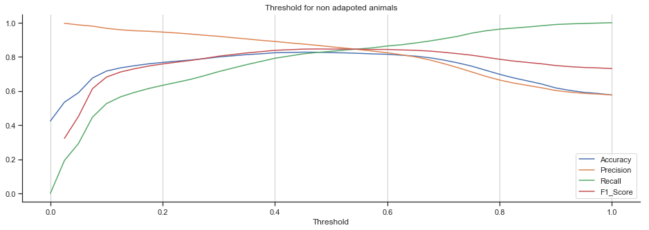

```python
add_plot(df_data_non_adopted, "Threshold for non adapoted animals")
```

### Save dogs!

Let's compare compare the different metrics:

**Accuracy***

Accuracy shows the percentags of dogs being adopted and not adopted. We don't know have if we many true positive or true negative, since it's just a sum of them over the toal.

**Precision**

Precisions shows percentags how many dogs predicted as adopted were correctly adopted and dogs which were adopted and we predicted them as not adopted, thus we might want to maximize this.

**Recall**

Recalls gives you what fractions of dogs which were adopted were correctly predicted. We might want to also maximize this.

**F1_Score**

Since F1 uses harmonic mean between precision and recall. As we want to maximize those two, we decided to find the threshold based on the F1 Score.

We want to use the adopted class for for maximizing the F1_Score, as we want to look at the adoptions we predicted as true, and the respective precision and recall.

[figure not shown]

# C

Reduce the number of features by selecting the subset of the k best features. Use greedy backward selection to iteratively remove features. Evaluate performance and visualize the result using 5-fold cross-validation on the training set as a function of k, where k = 1, 5, 10, 15, 20, 25, 30. Choose the optimal k and justify your choice. Interpret the top-k features and their impact on the probability of adoption.

```python
# Check all the features first, we see that we have 5 numerical
# and 27 categorical columns, which we will remove itteratively
feature_list = list(animals_training)
```

```python
def build_k_indices(y, k_fold, seed):
    """
    Function that builds k random indices from the length of the
    dataset for the cross validation
    Returns
       - random indeces from our dataset
    """
    num_row = y.shape[0]
    interval = int(num_row / k_fold)
    np.random.seed(seed)
    indices = np.random.permutation(num_row)
    k_indices = [indices[k * interval: (k + 1) * interval]
                 for k in range(k_fold)]

    return np.array(k_indices)

def cross_validation(y, x, k_indices, k, learn=1, estim=1, depth=1, choose = 1):
    '''
    Does the k-fold (5) split on the dataset and performs cross validation
    '''
    te_indice = k_indices[k]
    tr_indice = k_indices[~(np.arange(k_indices.shape[0]) == k)]
    tr_indice = tr_indice.reshape(-1)
    y_te_c = y[te_indice]
    y_tr_c = y[tr_indice]
    x_te_c = x[te_indice]
    x_tr_c = x[tr_indice]

    # Standartize both the datasets
    st_x_tr = standardize(x_tr_c)
    st_x_te = standardize(x_te_c)

    # local variable learn defines the type of models for training
    if learn == 1:
        logistic = LogisticRegression(solver='lbfgs').fit(st_x_tr,
                                                          y_tr_c)
        pred = logistic.predict_proba(st_x_te)[:,1]
        # 'choose' chooses the class with which accuracy, precision,
        # recall and f1_score is calculated
        if choose == 1:
            accu, prec, rec, f1 = build_confusion_matrix(get_prediction(pred, 0.5),y_te_c)
        else:
            accu, prec, rec, f1 = build_confusion_matrix(get_prediction(pred, 0.5),y_te_c, class_to_choose = 'non-adoted')
    else:
        forest = RandomForestClassifier(n_estimators=estim,
                                        max_depth=depth).fit(st_x_tr,
                                                            y_tr_c)
        pred = forest.predict(st_x_te)
        if choose == 1:
            accu, prec, rec, f1= build_confusion_matrix(pred, y_te_c)
        else:
            accu, prec, rec, f1= build_confusion_matrix(pred, y_te_c, class_to_choose = 'non-adpoted')
    return accu, prec, rec, f1

# Performs the cross validation testing on the data
def cross_val_test(y, x, learn = 1, estim=1, depth=1, choose = "adopted", f1 = 1):
    seed = 1
    k_fold = 5
    k_indices = build_k_indices(y, k_fold, seed)
    f1_full = []
    accu_full = []
    prec_full = []
    rec_full = []
    for i in range(k_fold):
        accu, prec, rec, f1 = cross_validation(y, x, k_indices, i, learn, estim=estim,
                                               depth=depth, choose = choose)
        f1_full.append(f1)
        accu_full.append(accu)
        prec_full.append(prec)
        rec_full.append(rec)
    return f1_full, accu_full, prec_full, rec_full
```

```python
# A function that runs a greedy algortihm that iteratively removes
# features from the dataset
def greedy_search(y, x, features):
    worst_list = []
    while len(features) >= 1:
        best = 0
        index = 0
        for i in range(len(features)):
            deleted = np.delete(x, i, axis = 1)
            accu_real, prec_real, rec_real, f1_alll = cross_val_test(y, deleted)
            #print(f1)
            if f1 > best:
                best = f1
                best_delete = features[i]
                index = i
        x = np.delete(x, index, axis = 1)
        worst = features.pop(index)
        worst_list.append(worst)
        print('Worst feature out of {} is the: '.format(len(features)), best_delete)
        print('F1 score with taking out the', best_delete,'is {}'.format(best))
    return worst_list
```

```python
from sklearn.datasets import load_iris
from sklearn.feature_selection import SelectKBest
from sklearn.feature_selection import chi2

ks = [1, 5, 10, 15, 20, 25, 30]
def find_features():
    result = []
    for k in ks:
        chi2_selector = SelectKBest(chi2, k = k)
        x_best = chi2_selector.fit_transform(x_tr, y_tr)
        f1_full, accu_full, prec_full, rec_full = cross_val_test(y_tr, x_best, f1=1)
        result.append(f1_full)
    return result
result = find_features()
```

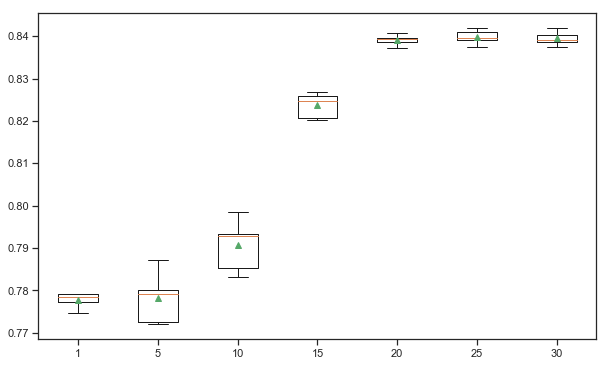

```python
def plot_scores(ks, result):
    fig1, ax1 = plt.subplots(figsize=(10, 6))
    ax1.boxplot(result, showmeans=True)
    plt.xticks(range(1, 8), ks)

plot_scores(ks, result);
```

**We show for k = 25 since it has the highest F1 score**

We created a function for greedily iterating over all the features, by maximizing the F1_score, and deleting the feature without which we have the highest F1 score. But as an online method of removing the features is time expensive, we decided to implement an offline method for removing the features, by using Chi-squared independence test, to greedily remove the worst features.

By visualizing the f1 scores in boxplots, we see that the best amount of features is 25, which makes sense for us, as by removing too many features we cannot make a reasonable prediction on our preferred class. And with too many features our model become too complex and overfits the data

# D

Train a random forest. Use 5-fold cross-validation on the training set to fine-tune the parameters of the classifier using a grid search on the number of estimators "n_estimators" and the max depth of the trees "max_depth". For the chosen parameters, estimate the performance of your classifier on the test set by presenting the confusion matrix, accuracy, precision, recall, and F1-score with respect to both classes and compare the performance with the performance of the logistic regression. Interpret the results.

```python
forest = RandomForestClassifier(n_estimators=100, max_depth=10)
```

```python
def grid_cross_val(y, x, class_to_choose = 1):
    '''
        This functions does grid watch for a predefined range of values.
        It only keeps the best outcome measure for that value.

        returns: a list of metrics for the best estimator and depth
    '''
    accuracy = 0
    precision = 0
    recall = 0
    f1_score = 0

    best_estimator = 0
    best_depth = 0
    best_f1_score = 0

    for estimator in np.linspace(start=80, stop=120, num=8).astype(int):
        for depth in np.linspace(start=6, stop=20, num=8).astype(int):
            if class_to_choose == "adopted":
                accu_, prec_, rec_, f1_ = cross_val_test(y, x, 2, estimator, depth)
            else:
                accu_, prec_, rec_, f1_ = cross_val_test(y, x, 2, estimator, depth, class_to_choose)

            mean_f1_score = np.mean(f1_, axis=0)
            if mean_f1_score > best_f1_score:
                best_f1_score = mean_f1_score
                accuracy = accu_
                precision = prec_
                recall  =  rec_
                f1_score = f1_
                best_estimator = estimator
                best_depth = depth

    return accuracy, precision, recall, f1_score, best_depth, best_estimator
```

```python
accuracy, precision, recall, f1_score, best_depth, best_estimator = grid_cross_val(y_tr, x_tr)
```

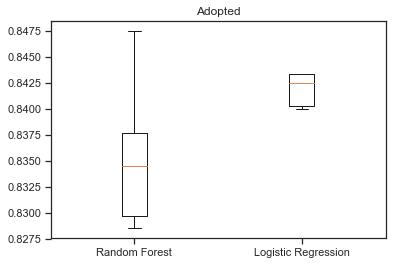

```python
f1_full, accu_full, prec_full, rec_full = cross_val_test(y_tr, x_tr, f1=1)

def show_plot(data):
    fig1, ax1 = plt.subplots()
    ax1.set_title('Adopted')
    ax1.boxplot(data)
    plt.xticks(range(1, 3), ['Random Forest', 'Logistic Regression'])

show_plot([f1_score, f1_full])
```

```python
print("Best Accuracy: ", np.round(np.mean(accuracy, axis=0), decimals=4))
print("Best Precision: ", np.round(np.mean(precision, axis=0), decimals=4))
print("Best Recall: ", np.round(np.mean(recall, axis=0), decimals=4))
print("Best F1 Score: ", np.round(np.mean(f1_score, axis=0), decimals=4))
print("Best Depth: ", best_depth)
print("Best Estimator: ", best_estimator)
```

```
Best Accuracy:  0.8609
Best Precision:  0.8435
Best Recall:  0.8884
Best F1 Score:  0.8356
Best Depth:  14
Best Estimator:  106
```

We evaluated that the best depth and estimator are 14 and 106.